# Reproducible Research: Storm Data Analysis

Roger Milligan

Sunday, June 21, 2015

Title  
## Analysis of NOAA Storm Database in order to determine which events are the most harmful to population health and which have the greatest economic consequences in terms of damage to property and crops.

## Synopsis

Storms and other severe weather events can cause both public health and economic problems for communities and municipalities. Many severe events can result in fatalities, injuries, and CROPerty damage, and preventing such outcomes to the extent possible is a key concern.

This project involves exploring the U.S. National Oceanic and Atmospheric Administration’s (NOAA) storm database. This database tracks characteristics of major storms and weather events in the United States, including when and where they occur, as well as estimates of any fatalities, injuries, and CROPerty damage.

## Data Processing

```r
#setwd("C:/Roger Docs/Documents/DS/ReprResearch/RepData_PeerAssessment2")
if (!file.exists("data")) {dir.create("data")}

filename <- "./data/StormData.csv.bz2"
if(!file.exists(filename)) {
        fileURL <- "http://d396qusza40orc.cloudfront.net/repdata%2Fdata%2FStormData.csv.bz2"
        download.file(fileURL, destfile = filename)
}
rawStormData <- read.csv(bzfile(filename), header = TRUE,  stringsAsFactors = FALSE)
#summary(rawStormData)
#str(rawStormData)
#dim(rawStormData)
#head(rawStormData, n = 2)
```

```r
columns <- c("EVTYPE", "FATALITIES", "INJURIES", "PROPDMG", "PROPDMGEXP", "CROPDMG", "CROPDMGEXP")
StormData <- rawStormData[columns]
```

### Data transformations

In order to calculate the economic impact of events (property plus crop damage), the damage figures need to be multiplied by the exponents. The exponents first need to be converted from 1,H,2,K,3,4,5,M,6,7,8,B to the power of 10. All exponents were converted to uppercase before processing.

Convert property damage exponents to numeric multipliers

```r
unique(StormData$PROPDMGEXP)
```

```
##  [1] "K" "M" ""  "B" "m" "+" "0" "5" "6" "?" "4" "2" "3" "h" "7" "H" "-"
## [18] "1" "8"
```

```r
StormData$PROPDMGEXP <- toupper(StormData$PROPDMGEXP)
StormData$PROPDMGMULT[StormData$PROPDMGEXP == "B"]   <- 1000000000
StormData$PROPDMGMULT[StormData$PROPDMGEXP == "8"]   <- 100000000
StormData$PROPDMGMULT[StormData$PROPDMGEXP == "7"]   <- 10000000
StormData$PROPDMGMULT[StormData$PROPDMGEXP == "M" | StormData$PROPDMGEXP == "6"] <- 1000000
StormData$PROPDMGMULT[StormData$PROPDMGEXP == "5"]   <- 100000
StormData$PROPDMGMULT[StormData$PROPDMGEXP == "4"]   <- 10000
StormData$PROPDMGMULT[StormData$PROPDMGEXP == "K" | StormData$PROPDMGEXP == "3"] <- 1000
StormData$PROPDMGMULT[StormData$PROPDMGEXP == "H" | StormData$PROPDMGEXP == "2"] <- 100
StormData$PROPDMGMULT[StormData$PROPDMGEXP == "1"]   <- 10
StormData$PROPDMGMULT[StormData$PROPDMGEXP == "" | StormData$PROPDMGEXP == "0"] <- 1
StormData$PROPDMGMULT[StormData$PROPDMGEXP == "+" | StormData$PROPDMGEXP == "-" | StormData$PROPDMGEXP == "?"] <- 0
unique(StormData$PROPDMGMULT)
```

```
##  [1] 1e+03 1e+06 1e+00 1e+09 0e+00 1e+05 1e+04 1e+02 1e+07 1e+01 1e+08
```

Convert crop damage exponents to numeric multipliers

```r
unique(StormData$CROPDMGEXP)
```

```
## [1] ""  "M" "K" "m" "B" "?" "0" "k" "2"
```

```r
StormData$CROPDMGEXP <- toupper(StormData$CROPDMGEXP)
StormData$CROPDMGMULT[StormData$CROPDMGEXP == "B"]   <- 1000000000
StormData$CROPDMGMULT[StormData$CROPDMGEXP == "8"]   <- 100000000
StormData$CROPDMGMULT[StormData$CROPDMGEXP == "7"]   <- 10000000
StormData$CROPDMGMULT[StormData$CROPDMGEXP == "M" | StormData$CROPDMGEXP == "6"] <- 1000000
StormData$CROPDMGMULT[StormData$CROPDMGEXP == "5"]   <- 100000
StormData$CROPDMGMULT[StormData$CROPDMGEXP == "4"]   <- 10000
StormData$CROPDMGMULT[StormData$CROPDMGEXP == "K" | StormData$CROPDMGEXP == "3"] <- 1000
StormData$CROPDMGMULT[StormData$CROPDMGEXP == "H" | StormData$CROPDMGEXP == "2"] <- 100
StormData$CROPDMGMULT[StormData$CROPDMGEXP == "1"]   <- 10
StormData$CROPDMGMULT[StormData$CROPDMGEXP == "" | StormData$CROPDMGEXP == "0"] <- 1
StormData$CROPDMGMULT[StormData$CROPDMGEXP == "+" | StormData$CROPDMGEXP == "-" | StormData$CROPDMGEXP == "?"] <- 0
unique(StormData$CROPDMGMULT)
```

```
## [1] 1e+00 1e+06 1e+03 1e+09 0e+00 1e+02
```

Calculate totaqal damage per event

```r
StormData$TOTDMG <- as.numeric(StormData$PROPDMG) * as.numeric(StormData$PROPDMGMULT) + as.numeric(StormData$CROPDMG) * as.numeric(StormData$CROPDMGMULT)
```

## Results

1. Which types of events are most harmful to population health? (Fatalities and Injuries are analysed separately as there is no given algorithm for determining the combined overall impact.)

Fatalities:

```r
FatSumm <- aggregate(FATALITIES ~ EVTYPE, StormData, sum)
TopFatSumm <- FatSumm[with(FatSumm, order(-FATALITIES)), ][1:8, ]
TopFatSumm
```

```
##             EVTYPE FATALITIES
## 834        TORNADO       5633
## 130 EXCESSIVE HEAT       1903
## 153    FLASH FLOOD        978
## 275           HEAT        937
## 464      LIGHTNING        816
## 856      TSTM WIND        504
## 170          FLOOD        470
## 585    RIP CURRENT        368
```

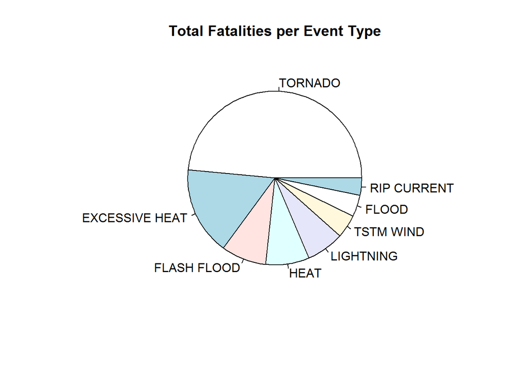

```r
pie(TopFatSumm$FATALITIES, labels = TopFatSumm$EVTYPE, main = "Total Fatalities per Event Type")
```

Tornado, Excessive Heat, Flash Flood, Heat and Lightning are the top 5 (in descending order) most harmful events in terms of fatalities.

Injuries:

```r
InjSumm <- aggregate(INJURIES ~ EVTYPE, StormData, sum)
TopInjSumm <- InjSumm[with(InjSumm, order(-INJURIES)), ][1:8, ]
TopInjSumm
```

```
##             EVTYPE INJURIES
## 834        TORNADO    91346
## 856      TSTM WIND     6957
## 170          FLOOD     6789
## 130 EXCESSIVE HEAT     6525
## 464      LIGHTNING     5230
## 275           HEAT     2100
## 427      ICE STORM     1975
## 153    FLASH FLOOD     1777
```

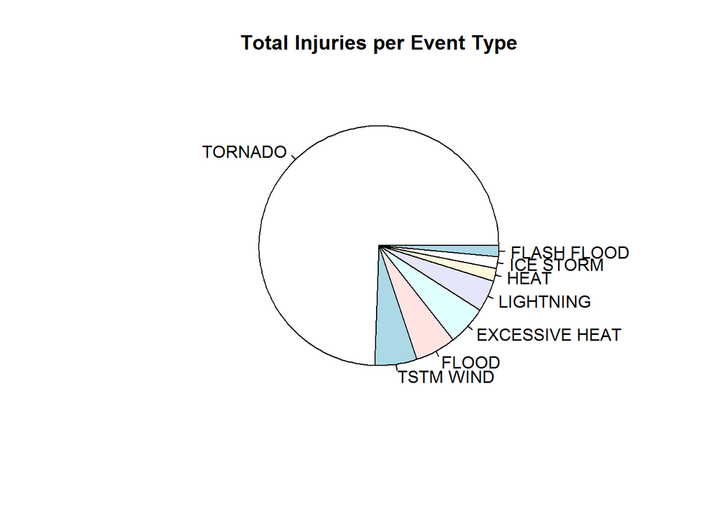

```r
pie(TopInjSumm$INJURIES, labels = TopInjSumm$EVTYPE,  main = "Total Injuries per Event Type")
```

Tornado, TSTM Wind, Flood, Excessive Heat and Lightning are the top 5 (in descending order) most harmful events in terms of injuries.

2. Which types of events have the greatest economic consequences?

```r
EcoDmgSumm <- aggregate(TOTDMG ~ EVTYPE, StormData, sum)
TopEcoDmgSumm <- EcoDmgSumm[with(EcoDmgSumm, order(-TOTDMG)), ][1:8, ]
TopEcoDmgSumm
```

```
##                EVTYPE       TOTDMG
## 170             FLOOD 150319678257
## 411 HURRICANE/TYPHOON  71913712800
## 834           TORNADO  57362333887
## 670       STORM SURGE  43323541000
## 244              HAIL  18761221986
## 153       FLASH FLOOD  18243991079
## 95            DROUGHT  15018672000
## 402         HURRICANE  14610229010
```

[figure not shown]

```r
pie(TopEcoDmgSumm$TOTDMG, labels = TopEcoDmgSumm$EVTYPE, main = "Total Injuries per Event Type")
```

Flood, Huricane/Typhoon, Tornado, Storm Surge and Hail are the top 5 (in descending order) most harmful events in terms of economic consequences due to damage to property and crops.